# Election PCA

## Principal Components Analysis

In this notebook, we go over principal components analysis as a dimensionality reduction tool, which is especially useful if our data comes in with many features, and we believe that the data can be sufficiently summarized with a lower-rank data matrix. The dimensionality reduction in itself can drive further analysis by revealing certain patterns, clusters, and/or trends in our data.

The simplest way to derive the PCA is through the **singular value decomposition (SVD)**.

Suppose our data is rectangular and quantitative, and let $\mathbb{X}\in\mathbb{R}^{n\times d}$ denote our data matrix, where $n,$ the number of rows, is the number of samples, and $d,$ the number of columns, is the number of features in our data.

To start, let us first import all our necessary libraries and generate a two-dimensional dataset. Note that PCA is sensitive to location and scale, so before doing PCA on any dataset, make sure to normalize it first.

```python
import numpy as np
import pandas as pd
import seaborn as sns
import matplotlib.pyplot as plt
%matplotlib inline
import plotly.express as px
```

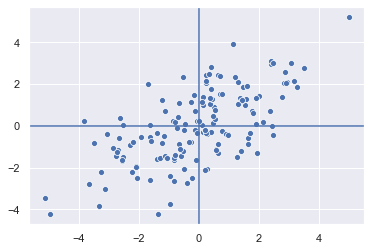

```python
X = np.random.multivariate_normal(mean=[0,0], cov=[[3, 2], [2, 3]], size=150)

# Visualize the dataset
sns.set()
sns.scatterplot(X[:,0], X[:,1]);
plt.axvline(0);
plt.axhline(0);
```

First, we normalize the dataset $\mathbb{X}.$ Now let us take the SVD: $\mathbb{X}=U\Sigma V^T,$ where $\Sigma$ is diagonal, and $U$ and $V$ are known to be orthogonal. Recall the intuition that if $\mathbb{X}$ were a transformation, then its action rotates Euclidean coordinates through $U,$ then scales according to $\Sigma$, and finally rotates back to Euclidean coordinates through $V^T.$ The diagonal entries $\sigma_i$ of $\Sigma$ are called the singular values of $\mathbb{X},$ and it can be shown that these are just the eigenvalues of $\mathbb{X}^T\mathbb{X}.$ The columns of $U$ are called the left singular vectors, and the columns of $V$ are called the right singular vectors. Lastly, the singular values are always nonnegative and by convention are in decreasing order, that is, $\sigma_1\geq\sigma_2\geq\cdots\geq\sigma_{\min\{n,d\}}.$

Simply put, principal components analysis (PCA) just rotates the coordinate axes so that axis 1 explains the most variance of the data, axis 2 explains the 2nd most variance, and so on. In fact, the total variance of $\mathbb{X}$ can be decomposed: $$\mathrm{Var}(\mathbb{X})=\frac{1}{n}\sum_{i=1}^d \sigma_i^2.$$

The **principal components** of $\mathbb{X}$ are the projections of the data onto these principal axes. For example, the first principal component of $\mathbb{X}$ is the axis corresponding to $\sigma_1.$ Therefore from the decomposition above, we can see exactly how much of the variance each principal component explains.

```python
# The total variance of X is the sum of the column variances
for i in range(X.shape[1]):
    X[:,i] = (X[:,i] - np.mean(X[:,i])) / np.std(X[:,i])
n, d = X.shape
total_var_X_direct = np.sum([np.var(X[:,i]) for i in range(d)])
total_var_X_direct
```

```
1.9999999999999996
```

```python
# Using the decomposition using singular values above
u, s, vt = np.linalg.svd(X)
total_var_X_sing_vals = np.sum(s ** 2) / n
total_var_X_sing_vals
```

```
1.9999999999999993
```

```python
# We can display how much of the variance is explained by each principal component.
var_explained_by_pc1 = s[0] ** 2 / n
var_explained_by_pc2 = s[1] ** 2 / n
print("Variance explained by 1st PC: ", var_explained_by_pc1)
print("Variance explained by 2nd PC: ", var_explained_by_pc2)
```

```
Variance explained by 1st PC:  1.653194277063916
Variance explained by 2nd PC:  0.34680572293608314
```

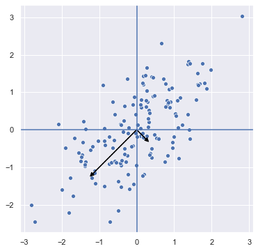

```python
# Get the principal component matrix
sns.set()
plt.figure(figsize=(6, 6))
sns.scatterplot(X[:,0], X[:,1]);
plt.axvline(0);
plt.axhline(0);

# We plot the axes directions to visualize the actual principal components on the dataset. These are precisely the rows of the
# pincipal component matrix. Note that for more accurate scaling of these principal components, we scale by the corresponding
# variance explained by that principal component.
plt.arrow(0, 0, s[0]**2/n * vt[0,0], s[0]**2/n * vt[0,1], color='black', width=0.01, head_width=0.1, head_length=0.1);
plt.arrow(0, 0, s[1]**2/n * vt[1,0], s[1]**2/n * vt[1,1], color='black', width=0.01, head_width=0.1, head_length=0.1);
```

The Eckart-Young Theorem states that the closest lower-rank matrix to $\mathbb{X}$ in the Frobenius-norm is the one obtained by throwing away the smallest singular values from $\Sigma.$ For example, if $\mathbb{X}$ were rank $d,$ then to get the best rank $d-k$ approximation to $\mathbb{X},$ we simply throw away the smallest $k$ singular values of $\mathbb{X}.$

Thus, we can also perform dimensionality reduction on a data set using principal components analysis as well, by simply looking at those most important principal components of a data set.

Now, let's apply what we know about PCA to a real high-dimensional dataset to gain some better insights that would have been impossible without performing PCA. Let's look at presidential election data, which we obtain from the table on the following Wikipedia page: https://en.wikipedia.org/wiki/List_of_United_States_presidential_election_results_by_state

We will use URL requests and Beautiful Soup libraries to extract the data from this page.

```python
import requests
from bs4 import BeautifulSoup

url = 'https://en.wikipedia.org/wiki/List_of_United_States_presidential_election_results_by_state'
res = requests.get(url)
soup = BeautifulSoup(res.content, "html.parser")

# Find all tables on the page, and observe that the table we want is the first table on the page
table = soup.find_all("tbody")[0]
```

```python
rowSoup = table.findChildren("tr")
```

```python
# First, we will gather the years to be the "features" of our dataset, as in the table on the page
yearSoup = rowSoup[0].findChildren("th")[1:]
years = []
for y in yearSoup[:-1]:
    years.append(y.findAll(text=True)[0])

# Initialize the dataframe "elections" with years as the features
elections = pd.DataFrame(years)
```

```python
# Then, gather the names of all the states in the order given in the table, namely, alphabetical order.
# After looking through the HTML, we see that the actual state names are in the 1st through 52nd indices of rowSoup,
# where we note that one row repeates the word 'State\n'
states = []
for row in rowSoup[1:53]:
    state = row.findAll(text=True)[1]
    states.append(state)
```

```python
# Initialize the pandas data frame as "elections"
elections = pd.DataFrame(index=states, columns=years)
elections.index.name = 'State'
elections.head(5)
```

| State | 1789 | 1792 | 1796 | 1800 | 1804 | 1808 | 1812 | 1816 | 1820 | 1824 | ... | 1980 | 1984 | 1988 | 1992 | 1996 | 2000 | 2004 | 2008 | 2012 | 2016 |
| --- | --- | --- | --- | --- | --- | --- | --- | --- | --- | --- | --- | --- | --- | --- | --- | --- | --- | --- | --- | --- | --- |
| Alabama | NaN | NaN | NaN | NaN | NaN | NaN | NaN | NaN | NaN | NaN | ... | NaN | NaN | NaN | NaN | NaN | NaN | NaN | NaN | NaN | NaN |
| Alaska | NaN | NaN | NaN | NaN | NaN | NaN | NaN | NaN | NaN | NaN | ... | NaN | NaN | NaN | NaN | NaN | NaN | NaN | NaN | NaN | NaN |
| Arizona | NaN | NaN | NaN | NaN | NaN | NaN | NaN | NaN | NaN | NaN | ... | NaN | NaN | NaN | NaN | NaN | NaN | NaN | NaN | NaN | NaN |
| Arkansas | NaN | NaN | NaN | NaN | NaN | NaN | NaN | NaN | NaN | NaN | ... | NaN | NaN | NaN | NaN | NaN | NaN | NaN | NaN | NaN | NaN |
| California | NaN | NaN | NaN | NaN | NaN | NaN | NaN | NaN | NaN | NaN | ... | NaN | NaN | NaN | NaN | NaN | NaN | NaN | NaN | NaN | NaN |

5 rows × 58 columns

```python
# Populate the dataframe with the corresponding data. Since we are using rowSoup, we still have to deal with the extraneous
# row labeled 'State\n', which lists all the years again. Observe that in this case, the obtained row is [], an empty list.
for i in range(52):
    row = rowSoup[i+1].findChildren("td")
    if row == []:
        continue
    for j in range(len(years)):
        elections.iloc[i,j] = row[j].findAll(text=True)[0]
```

```python
elections = elections.drop('State\n', axis=0)
elections.head(10)
```

| State | 1789 | 1792 | 1796 | 1800 | 1804 | 1808 | 1812 | 1816 | 1820 | 1824 | ... | 1980 | 1984 | 1988 | 1992 | 1996 | 2000 | 2004 | 2008 | 2012 | 2016 |
| --- | --- | --- | --- | --- | --- | --- | --- | --- | --- | --- | --- | --- | --- | --- | --- | --- | --- | --- | --- | --- | --- |
| Alabama | \n | \n | \n | \n | \n | \n | \n | \n | DR | Jackson\n | ... | R | R | R | R\n | R\n | R | R | R\n | R\n | R |
| Alaska | \n | \n | \n | \n | \n | \n | \n | \n | \n | \n | ... | R | R | R | R\n | R\n | R | R | R\n | R\n | R |
| Arizona | \n | \n | \n | \n | \n | \n | \n | \n | \n | \n | ... | R | R | R | R\n | D | R | R | R\n | R\n | R |
| Arkansas | \n | \n | \n | \n | \n | \n | \n | \n | \n | \n | ... | R | R | R | D | D | R | R | R\n | R\n | R |
| California | \n | \n | \n | \n | \n | \n | \n | \n | \n | \n | ... | R | R | R | D | D | D\n | D\n | D | D | D\n |
| Colorado | \n | \n | \n | \n | \n | \n | \n | \n | \n | \n | ... | R | R | R | D | R\n | R | R | D | D | D\n |
| Connecticut | GW | GW | F | F\n | F\n | F\n | F\n | F\n | DR | Adams | ... | R | R | R | D | D | D\n | D\n | D | D | D\n |
| Delaware | GW | GW | F | F\n | F\n | F\n | F\n | F\n | DR | Crawford\n | ... | R | R | R | D | D | D\n | D\n | D | D | D\n |
| D.C. | \n | \n | \n | \n | \n | \n | \n | \n | \n | \n | ... | D\n | D\n | D\n | D | D | D\n | D\n | D | D | D\n |
| Florida | \n | \n | \n | \n | \n | \n | \n | \n | \n | \n | ... | R | R | R | R\n | D | R | R | D | D | R |

10 rows × 58 columns

```python
states.remove('State\n')
```

For simplicity, let us look at the years from 1972 to 2016. Then, we are able to have every state participate in every election, voting either Republican (R) or Democrat (D). We then quantify the data: in particular, we replace every R with 0 and every D with 1.

```python
# We also remove the row labeled 'State\n'
elections_since_1972 = elections.loc[:,'1972':'2016']
elections_since_1972 = elections_since_1972.replace({'R':0, 'D':1, 'R\n':0, 'D\n':1})
elections_since_1972.head(10)
```

| State | 1972 | 1976 | 1980 | 1984 | 1988 | 1992 | 1996 | 2000 | 2004 | 2008 | 2012 | 2016 |
| --- | --- | --- | --- | --- | --- | --- | --- | --- | --- | --- | --- | --- |
| Alabama | 0 | 1 | 0 | 0 | 0 | 0 | 0 | 0 | 0 | 0 | 0 | 0 |
| Alaska | 0 | 0 | 0 | 0 | 0 | 0 | 0 | 0 | 0 | 0 | 0 | 0 |
| Arizona | 0 | 0 | 0 | 0 | 0 | 0 | 1 | 0 | 0 | 0 | 0 | 0 |
| Arkansas | 0 | 1 | 0 | 0 | 0 | 1 | 1 | 0 | 0 | 0 | 0 | 0 |
| California | 0 | 0 | 0 | 0 | 0 | 1 | 1 | 1 | 1 | 1 | 1 | 1 |
| Colorado | 0 | 0 | 0 | 0 | 0 | 1 | 0 | 0 | 0 | 1 | 1 | 1 |
| Connecticut | 0 | 0 | 0 | 0 | 0 | 1 | 1 | 1 | 1 | 1 | 1 | 1 |
| Delaware | 0 | 1 | 0 | 0 | 0 | 1 | 1 | 1 | 1 | 1 | 1 | 1 |
| D.C. | 1 | 1 | 1 | 1 | 1 | 1 | 1 | 1 | 1 | 1 | 1 | 1 |
| Florida | 0 | 1 | 0 | 0 | 0 | 0 | 1 | 0 | 0 | 1 | 1 | 0 |

```python
# To prepare for our PCA, we will center and scale the data
elections_since_1972_norm = elections_since_1972.apply(lambda x: (x - np.mean(x)) / np.std(x), axis=0)
```

```python
# Take the SVD of the normalized dataset, then take the first 2 principal components
u, s, vt = np.linalg.svd(elections_since_1972_norm)
pcs = elections_since_1972_norm @ vt.T
first_2_pcs = pcs[[0,1]]
```

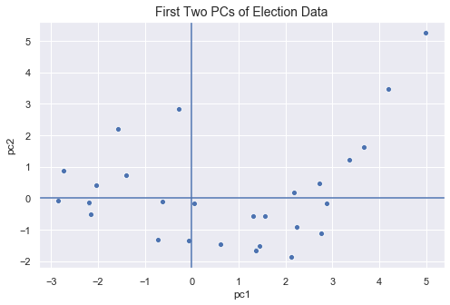

```python
# We plot the first 2 principal components
plt.figure(figsize=(8, 5))
sns.scatterplot(data = first_2_pcs, x = 0, y = 1)
plt.title("First Two PCs of Election Data", fontsize=14)
plt.xlabel("pc1")
plt.ylabel("pc2")
plt.axvline(0)
plt.axhline(0);
```

We should have 51 data points on our plot, but that is not noticeable from the graph above. Indeed, there is overfitting in our plot, where some points lie on top of other points, so we add jitter to help our visualization.

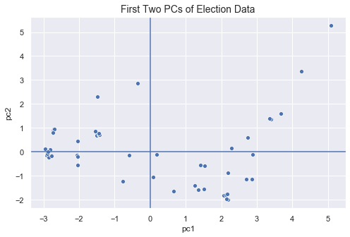

```python
# We plot the first 2 principal components
first_2_pcs_jitter = first_2_pcs + np.random.normal(0, 0.1, size = (len(first_2_pcs), 2))
plt.figure(figsize=(8, 5))
sns.scatterplot(data = first_2_pcs_jitter, x = 0, y = 1)
plt.title("First Two PCs of Election Data", fontsize=14)
plt.xlabel("pc1")
plt.ylabel("pc2")
plt.axvline(0)
plt.axhline(0)
plt.show()
```

To best analyze these results, we need to know the label of each point - that is, we know each datapoint corresponds to a state. To do this, we use the plotly library, which allows us to create an interactive plot of this data, including labels for each point. This gives us an excellent way to analyze our data.

```python
elections_since_1972[first_2_pcs[1] < 0].loc[:,'1972':'1988']
elections_since_1972.loc['Florida',:]
```

```
1972    0
1976    1
1980    0
1984    0
1988    0
1992    0
1996    1
2000    0
2004    0
2008    1
2012    1
2016    0
Name: Florida, dtype: int64
```

```python
fig = px.scatter(data_frame=first_2_pcs_jitter.reset_index(), x=0, y=1, text=np.array(states))

fig.update_traces(textposition='top center')

fig.update_layout(
    height=800,
    title_text='Principal Components of State Party Preferences from 1972 to 2016',
    xaxis_title='PC 1',
    yaxis_title='PC 2'
)

fig.show()
```

[interactive chart not shown]

Let's first analyze the states that voted very similarly in these elections. Particularly, towards the left side of the plot, we observe a cluster consisting of the states Mississippi, Texas, Alabama, and South Carolina, with a nearby cluster consisting of Tennessee, Arkansas, Missouri, Kentucky, and Louisiana. Unsurprisingly, these are mostly Southern states, which tend to vote very similarly (Republican). Furthermore, toward the bottom-right of the plot, we notice another cluster of states: Connecticut, New Jersey, Illinois, California, and Vermont, which also tend to vote similarly (Democrat).

Indeed, datapoints that lie left of the $y$-axis, i.e., points in which their corresponding $\text{PC 1} < 0,$ represent states that stereotypically vote Republican. Concretely, we also notice that these are rural or Southern states. Likewise, states where $\text{PC 1} > 0$ are indeed states that tend to vote Democrat. We also see the two swing states (Florida and Ohio) which in a sense basically decide entire elections, are very close to the origin, quantifying this fact.

After analysis of some of the states' actual election history, we notice that the states in the far left cluster (containing Kansas, Nebraska, Utah, etc.) voted Republican in every election, while D.C. is the only "state" that voted all Democrat. The more times a state voted Democrat, the higher their value of the first principal component. On the plot, this means that they appeared further to the right. Thus, it is reasonable to conclude that the first principal component quantifies a state's political ideology, with respect to the two-party system (Republican-leaning or Democrat-leaning) since 1972.

Note that in practice, principal components beyond the first are often difficult to interpret. However, in this example, we can attempt to better interpret the principal components by plotting the contributions of each column - the results for each year's election in this case - to the values of the principal components. Concretely, the contribution of the $j$-th column of the data matrix $\mathbb{X}$ to the values in the $i$-th principal component is the $ij$-th entry of $V^T$ in the SVD of $\mathbb{X}.$

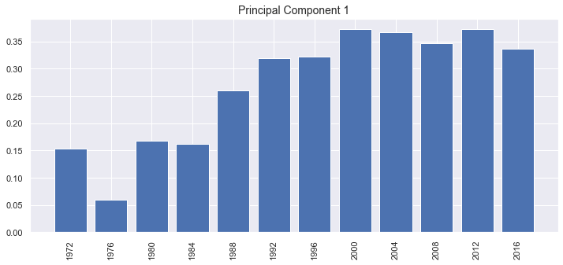

```python
def pc_plot(df_colnames, vt, pc_num):
    # This function plots the extent to which each column contributes to the principal component in question
    # where pc_num increases starting from 0, the most important principal component.
    plt.bar(df_colnames, vt[pc_num, :])
    plt.xticks(df_colnames, rotation=90);

with plt.rc_context({"figure.figsize": (12, 5)}):
    pc_plot(list(elections_since_1972), vt, 0)
    plt.title("Principal Component 1", fontsize=14)
```

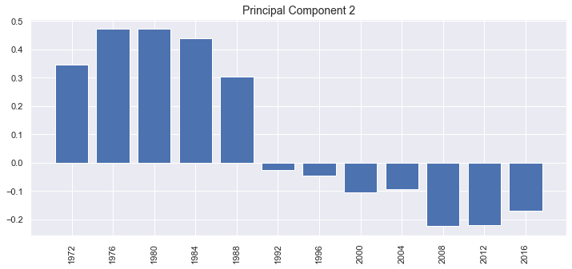

```python
with plt.rc_context({"figure.figsize": (12, 5)}):
    pc_plot(list(elections_since_1972), vt, 1)
    plt.title("Principal Component 2", fontsize=14)
```

From the first plot corresponding to Principal Component 1 above, we see that the partisan divide has generally been increasing since 1972. Indeed, in today's political climate, for most states it is very easy to predict how they will vote in presidential elections. Of course, this was not always the case: California voted for Ronald Reagan, a Republican, twice. More recent elections place a bigger weight on the first principal component, thus from our conclusion above, on whether the state tends to be more Republican or Democrat in nature.